# Lab 3 - Análisis Exploratorio de Datos y Agrupamiento

Jose Sanchez, Roberto Najera

2026-03-13

# 1 Introducción

Este informe presenta el análisis exploratorio del conjunto de datos **listings**, el cual corresponde a publicaciones de alojamientos de Airbnb en distintas ciudades de Estados Unidos. El dataset contiene **171.748 registros** y **80 variables** que describen características de los alojamientos, los anfitriones, la disponibilidad, los precios y las reseñas de los huéspedes.

El objetivo es comprender la distribución y estructura de los datos mediante técnicas de análisis exploratorio y agrupamiento (clustering).

# 2 Carga de Librerías y Datos

```r
library(tidyverse)
library(ggplot2)
library(scales)
library(cluster)
library(factoextra)
library(knitr)
library(kableExtra)
library(corrplot)
```

```r
load("listings.RData")
cat("Dimensiones del dataset:", nrow(listings), "filas x", ncol(listings), "columnas\n")
```

```
## Dimensiones del dataset: 171748 filas x 80 columnas
```

# 3 Descripción del Dataset

El dataset incluye información de alojamientos en 10 ciudades/regiones de EE.UU.:

```r
ciudad_tabla <- listings %>%
  count(city, name = "n_listings") %>%
  arrange(desc(n_listings)) %>%
  mutate(porcentaje = round(n_listings / sum(n_listings) * 100, 1))

kable(ciudad_tabla, col.names = c("Ciudad", "N° Listings", "% del Total"),
      caption = "Distribución de listings por ciudad") %>%
  kable_styling(bootstrap_options = c("striped", "hover"), full_width = FALSE)
```

Distribución de listings por ciudad

| Ciudad | N° Listings | % del Total |
| --- | --- | --- |
| Los Angeles, California | 45585 | 26.5 |
| New York, New York | 36261 | 21.1 |
| Hawaii | 33457 | 19.5 |
| San Diego, California | 13162 | 7.7 |
| Austin, Texas | 10533 | 6.1 |
| Chicago, Illinois | 8660 | 5.0 |
| San Francisco, California | 7535 | 4.4 |
| Washington, D.C. | 6374 | 3.7 |
| Rhode Island | 5762 | 3.4 |
| Boston, Massachusetts | 4419 | 2.6 |

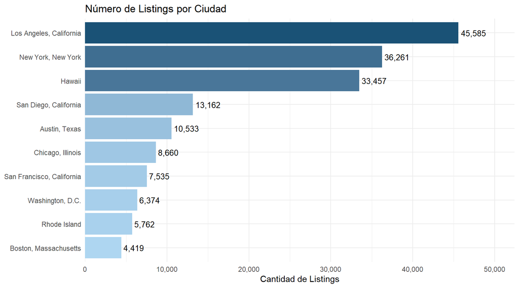

```r
ggplot(ciudad_tabla, aes(x = reorder(city, n_listings), y = n_listings, fill = n_listings)) +
  geom_col(show.legend = FALSE) +
  geom_text(aes(label = comma(n_listings)), hjust = -0.1, size = 3.5) +
  coord_flip() +
  scale_fill_gradient(low = "#AED6F1", high = "#1A5276") +
  scale_y_continuous(labels = comma, expand = expansion(mult = c(0, 0.15))) +
  labs(title = "Número de Listings por Ciudad",
       x = NULL, y = "Cantidad de Listings") +
  theme_minimal()
```

# 4 Análisis Exploratorio

## 4.1 Limpieza y Preparación

```r
# Convertir precio a numérico
listings <- listings %>%
  mutate(price_num = as.numeric(gsub("[$,]", "", price)))

# Filtrar precios razonables para el análisis (percentil 1-99)
p1 <- quantile(listings$price_num, 0.01, na.rm = TRUE)
p99 <- quantile(listings$price_num, 0.99, na.rm = TRUE)

listings_clean <- listings %>%
  filter(!is.na(price_num),
         price_num >= p1, price_num <= p99,
         !is.na(review_scores_rating),
         !is.na(bedrooms),
         !is.na(accommodates))

cat("Registros tras limpieza:", nrow(listings_clean), "\n")
```

```
## Registros tras limpieza: 62107
```

## 4.2 Valores Faltantes

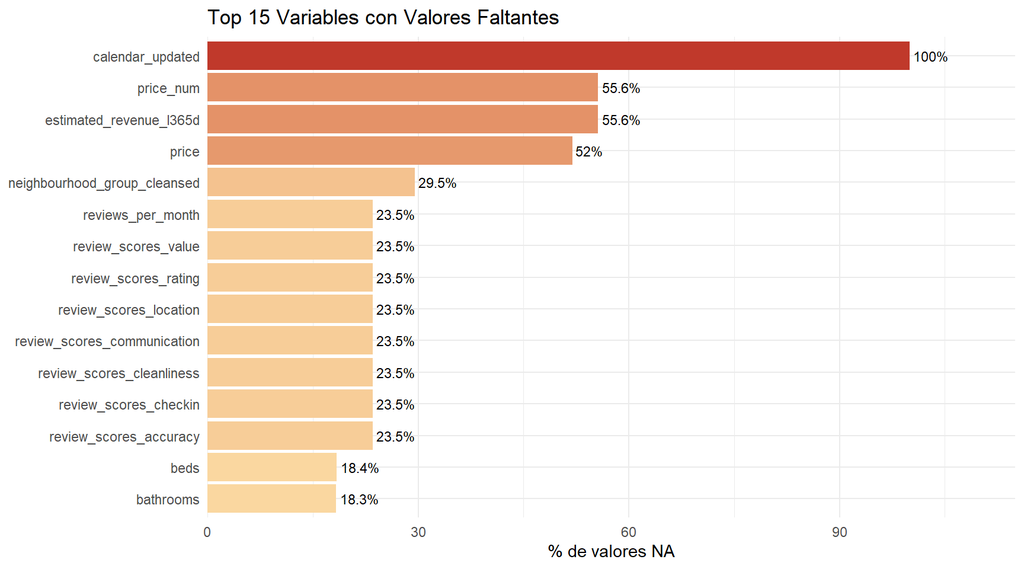

```r
na_resumen <- listings %>%
  summarise(across(everything(), ~sum(is.na(.)))) %>%
  pivot_longer(everything(), names_to = "variable", values_to = "na_count") %>%
  filter(na_count > 0) %>%
  mutate(porcentaje = round(na_count / nrow(listings) * 100, 1)) %>%
  arrange(desc(na_count)) %>%
  head(15)

ggplot(na_resumen, aes(x = reorder(variable, porcentaje), y = porcentaje, fill = porcentaje)) +
  geom_col(show.legend = FALSE) +
  geom_text(aes(label = paste0(porcentaje, "%")), hjust = -0.1, size = 3) +
  coord_flip() +
  scale_fill_gradient(low = "#FAD7A0", high = "#C0392B") +
  scale_y_continuous(expand = expansion(mult = c(0, 0.15))) +
  labs(title = "Top 15 Variables con Valores Faltantes",
       x = NULL, y = "% de valores NA") +
  theme_minimal()
```

Se destacan `calendar_updated` (100% NA), `estimated_revenue_l365d` (~56% NA) y `price` (~52% NA) como las variables con más datos faltantes.

## 4.3 Distribución del Precio

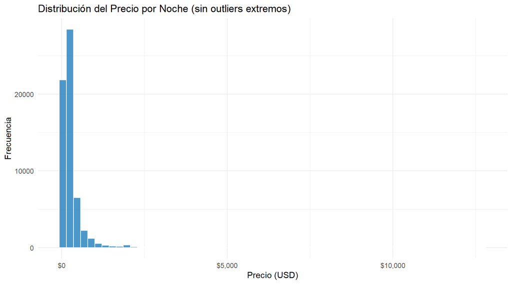

```r
ggplot(listings_clean, aes(x = price_num)) +
  geom_histogram(bins = 60, fill = "#2E86C1", color = "white", alpha = 0.85) +
  scale_x_continuous(labels = dollar) +
  labs(title = "Distribución del Precio por Noche (sin outliers extremos)",
       x = "Precio (USD)", y = "Frecuencia") +
  theme_minimal()
```

```r
listings_clean %>%
  group_by(city) %>%
  summarise(mediana = median(price_num),
            media = mean(price_num),
            q25 = quantile(price_num, 0.25),
            q75 = quantile(price_num, 0.75)) %>%
  arrange(desc(mediana)) %>%
  kable(digits = 1,
        col.names = c("Ciudad", "Mediana", "Media", "Q25", "Q75"),
        caption = "Estadísticas de precio (USD) por ciudad") %>%
  kable_styling(bootstrap_options = c("striped", "hover"), full_width = FALSE)
```

Estadísticas de precio (USD) por ciudad

| Ciudad | Mediana | Media | Q25 | Q75 |
| --- | --- | --- | --- | --- |
| Rhode Island | 265.5 | 349.0 | 154 | 432 |
| Hawaii | 217.0 | 367.0 | 148 | 347 |
| Boston, Massachusetts | 194.0 | 241.5 | 118 | 299 |
| San Diego, California | 175.0 | 258.2 | 115 | 294 |
| Chicago, Illinois | 146.0 | 202.7 | 98 | 232 |
| Austin, Texas | 132.0 | 217.3 | 88 | 218 |
| Washington, D.C. | 124.0 | 166.8 | 89 | 181 |

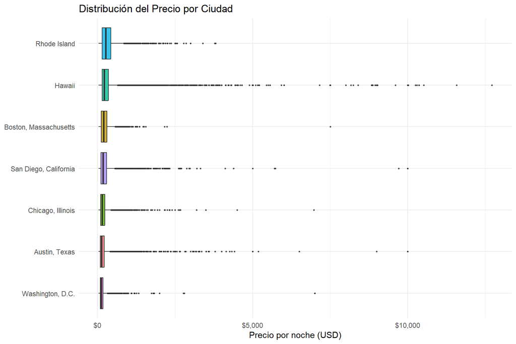

```r
ggplot(listings_clean, aes(x = reorder(city, price_num, FUN = median), y = price_num, fill = city)) +
  geom_boxplot(show.legend = FALSE, outlier.size = 0.5, alpha = 0.8) +
  coord_flip() +
  scale_y_continuous(labels = dollar) +
  labs(title = "Distribución del Precio por Ciudad",
       x = NULL, y = "Precio por noche (USD)") +
  theme_minimal()
```

## 4.4 Tipos de Alojamiento

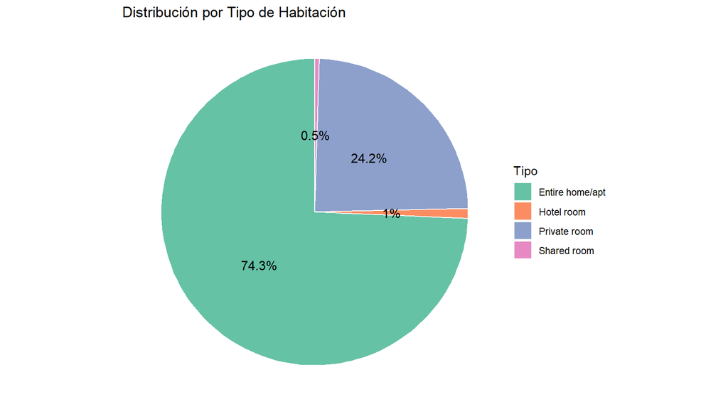

```r
room_tabla <- listings %>%
  count(room_type, name = "n") %>%
  mutate(porcentaje = round(n / sum(n) * 100, 1)) %>%
  arrange(desc(n))

ggplot(room_tabla, aes(x = "", y = n, fill = room_type)) +
  geom_col(width = 1, color = "white") +
  coord_polar(theta = "y") +
  geom_text(aes(label = paste0(porcentaje, "%")),
            position = position_stack(vjust = 0.5), size = 4) +
  scale_fill_brewer(palette = "Set2") +
  labs(title = "Distribución por Tipo de Habitación",
       fill = "Tipo", x = NULL, y = NULL) +
  theme_void()
```

```r
listings_clean %>%
  group_by(room_type) %>%
  summarise(n = n(),
            precio_mediana = median(price_num),
            precio_media = mean(price_num)) %>%
  arrange(desc(precio_mediana)) %>%
  kable(digits = 1,
        col.names = c("Tipo de Habitación", "N°", "Precio Mediana (USD)", "Precio Media (USD)"),
        caption = "Precio por tipo de habitación") %>%
  kable_styling(bootstrap_options = c("striped", "hover"), full_width = FALSE)
```

Precio por tipo de habitación

| Tipo de Habitación | N° | Precio Mediana (USD) | Precio Media (USD) |
| --- | --- | --- | --- |
| Hotel room | 131 | 247 | 304.2 |
| Entire home/apt | 54800 | 196 | 311.7 |
| Private room | 7070 | 83 | 143.0 |
| Shared room | 106 | 49 | 271.2 |

## 4.5 Capacidad (Huéspedes)

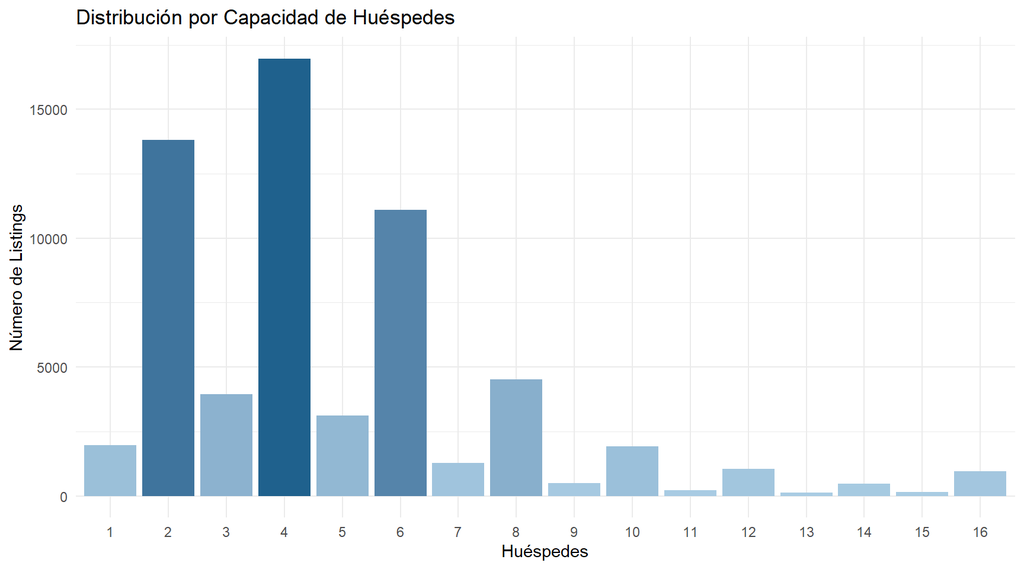

```r
listings_clean %>%
  count(accommodates) %>%
  mutate(porcentaje = round(n / sum(n) * 100, 1)) %>%
  ggplot(aes(x = factor(accommodates), y = n, fill = n)) +
  geom_col(show.legend = FALSE) +
  scale_fill_gradient(low = "#A9CCE3", high = "#1F618D") +
  labs(title = "Distribución por Capacidad de Huéspedes",
       x = "Huéspedes", y = "Número de Listings") +
  theme_minimal()
```

## 4.6 Puntajes de Reseñas

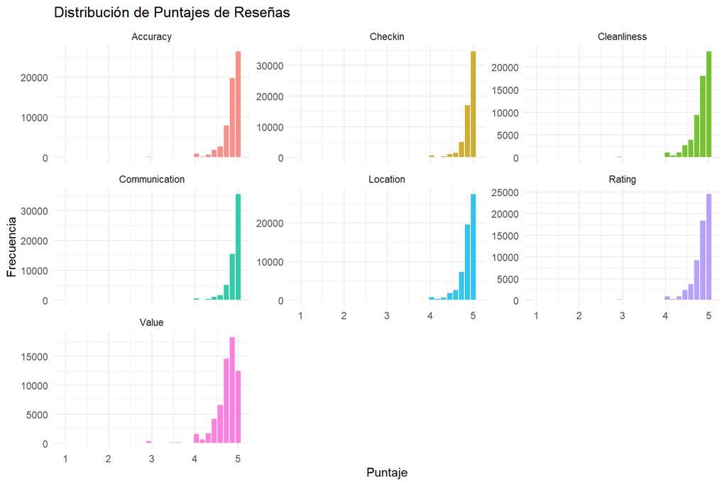

```r
review_cols <- c("review_scores_rating", "review_scores_accuracy",
                 "review_scores_cleanliness", "review_scores_checkin",
                 "review_scores_communication", "review_scores_location",
                 "review_scores_value")

listings_clean %>%
  select(all_of(review_cols)) %>%
  pivot_longer(everything(), names_to = "categoria", values_to = "puntaje") %>%
  filter(!is.na(puntaje)) %>%
  mutate(categoria = str_replace(categoria, "review_scores_", "") %>%
           str_to_title()) %>%
  ggplot(aes(x = puntaje, fill = categoria)) +
  geom_histogram(bins = 30, show.legend = FALSE, color = "white", alpha = 0.8) +
  facet_wrap(~categoria, scales = "free_y") +
  labs(title = "Distribución de Puntajes de Reseñas",
       x = "Puntaje", y = "Frecuencia") +
  theme_minimal()
```

```r
listings_clean %>%
  group_by(city) %>%
  summarise(rating_promedio = round(mean(review_scores_rating, na.rm = TRUE), 3)) %>%
  arrange(desc(rating_promedio)) %>%
  kable(col.names = c("Ciudad", "Rating Promedio"),
        caption = "Rating promedio por ciudad") %>%
  kable_styling(bootstrap_options = c("striped", "hover"), full_width = FALSE)
```

Rating promedio por ciudad

| Ciudad | Rating Promedio |
| --- | --- |
| Austin, Texas | 4.844 |
| Rhode Island | 4.833 |
| San Diego, California | 4.823 |
| Washington, D.C. | 4.800 |
| Hawaii | 4.795 |
| Chicago, Illinois | 4.776 |
| Boston, Massachusetts | 4.738 |

## 4.7 Correlación entre Variables Numéricas

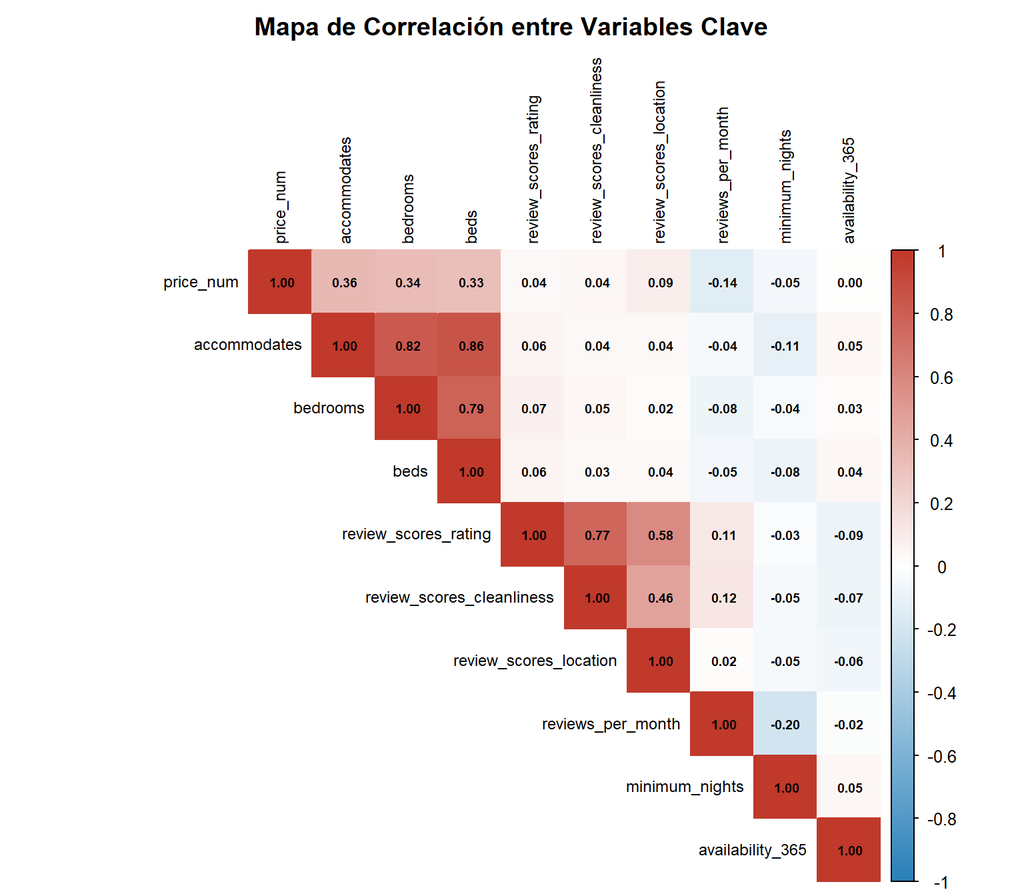

```r
vars_corr <- listings_clean %>%
  select(price_num, accommodates, bedrooms, beds,
         review_scores_rating, review_scores_cleanliness,
         review_scores_location, reviews_per_month,
         minimum_nights, availability_365) %>%
  drop_na()

cor_matrix <- cor(vars_corr)

corrplot(cor_matrix, method = "color", type = "upper",
         tl.cex = 0.75, tl.col = "black",
         addCoef.col = "black", number.cex = 0.6,
         col = colorRampPalette(c("#2980B9", "white", "#C0392B"))(200),
         title = "Mapa de Correlación entre Variables Clave",
         mar = c(0, 0, 2, 0))
```

Se observa una correlación positiva entre `accommodates`, `bedrooms` y `beds`, lo cual es lógico. El precio también muestra correlación positiva con la capacidad.

# 5 Análisis de Agrupamiento (Clustering)

## 5.1 Preparación de Datos para Clustering

```r
set.seed(42)

datos_cluster <- listings_clean %>%
  select(price_num, accommodates, bedrooms,
         review_scores_rating, minimum_nights, availability_365) %>%
  drop_na() %>%
  sample_n(min(8000, nrow(.)))  # muestra para eficiencia computacional

# Estandarización Z-score
datos_scaled <- scale(datos_cluster)

cat("Registros usados para clustering:", nrow(datos_cluster), "\n")
```

```
## Registros usados para clustering: 8000
```

```r
cat("Variables:", colnames(datos_cluster), "\n")
```

```
## Variables: price_num accommodates bedrooms review_scores_rating minimum_nights availability_365
```

## 5.2 Determinación del Número Óptimo de Clusters

### 5.2.1 Método del Codo (Elbow)

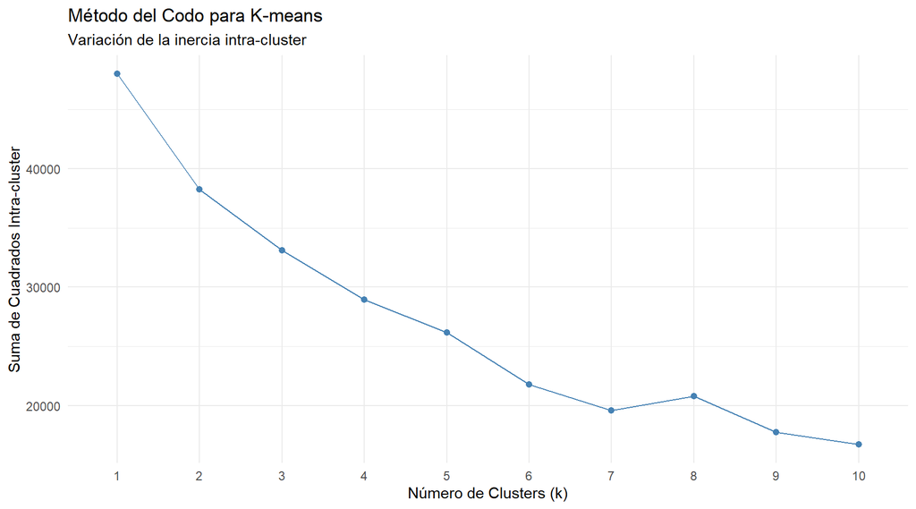

```r
fviz_nbclust(datos_scaled, kmeans, method = "wss",
             k.max = 10, nboot = 20) +
  labs(title = "Método del Codo para K-means",
       subtitle = "Variación de la inercia intra-cluster",
       x = "Número de Clusters (k)", y = "Suma de Cuadrados Intra-cluster") +
  theme_minimal()
```

### 5.2.2 Método de la Silueta

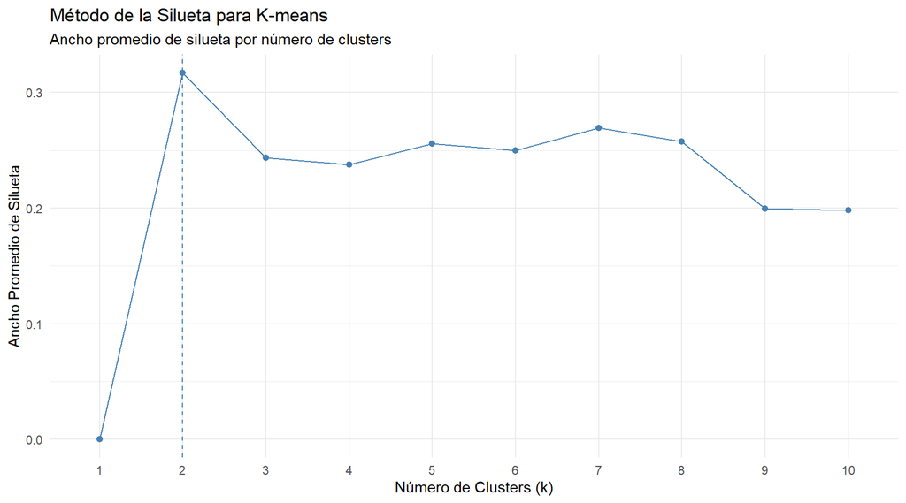

```r
fviz_nbclust(datos_scaled, kmeans, method = "silhouette",
             k.max = 10, nboot = 20) +
  labs(title = "Método de la Silueta para K-means",
       subtitle = "Ancho promedio de silueta por número de clusters",
       x = "Número de Clusters (k)", y = "Ancho Promedio de Silueta") +
  theme_minimal()
```

## 5.3 Aplicación de K-means

```r
set.seed(42)
k_optimo <- 4
modelo_kmeans <- kmeans(datos_scaled, centers = k_optimo, nstart = 25, iter.max = 100)

datos_cluster$cluster <- factor(modelo_kmeans$cluster)
cat("Tamaño de cada cluster:\n")
```

```
## Tamaño de cada cluster:
```

```r
print(table(datos_cluster$cluster))
```

```
##
##    1    2    3    4
## 1531 2395 4052   22
```

## 5.4 Visualización de Clusters

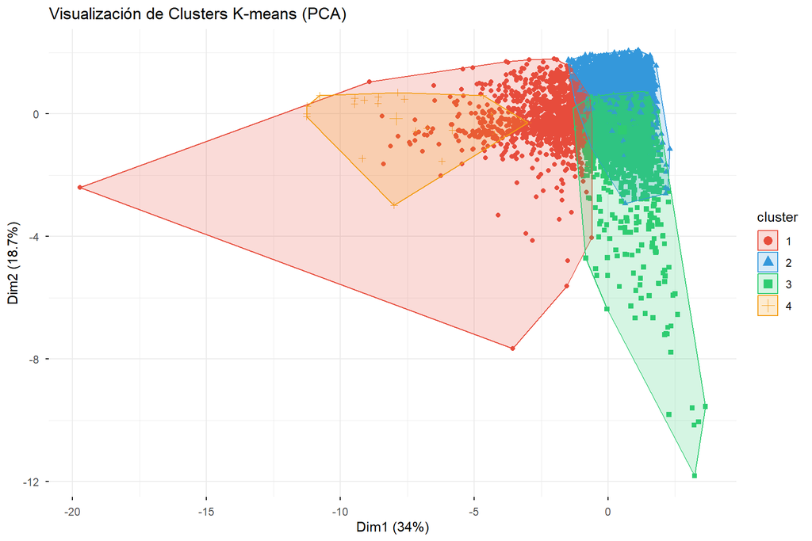

```r
fviz_cluster(modelo_kmeans, data = datos_scaled,
             geom = "point", ellipse.type = "convex",
             palette = c("#E74C3C", "#3498DB", "#2ECC71", "#F39C12"),
             ggtheme = theme_minimal(),
             main = "Visualización de Clusters K-means (PCA)")
```

## 5.5 Perfiles de los Clusters

```r
perfil_clusters <- datos_cluster %>%
  group_by(cluster) %>%
  summarise(
    n = n(),
    precio_mediana = round(median(price_num), 0),
    capacidad_media = round(mean(accommodates), 1),
    habitaciones_media = round(mean(bedrooms), 1),
    rating_medio = round(mean(review_scores_rating), 2),
    min_noches_mediana = round(median(minimum_nights), 0),
    disponibilidad_media = round(mean(availability_365), 0)
  )

kable(perfil_clusters,
      col.names = c("Cluster", "N°", "Precio Mediana ($)", "Capacidad Media",
                    "Habitaciones Media", "Rating Medio",
                    "Min. Noches Mediana", "Disponibilidad Media (días/año)"),
      caption = "Perfil de cada cluster") %>%
  kable_styling(bootstrap_options = c("striped", "hover"), full_width = FALSE)
```

Perfil de cada cluster

| Cluster | N° | Precio Mediana ($) | Capacidad Media | Habitaciones Media | Rating Medio | Min. Noches Mediana | Disponibilidad Media (días/año) |
| --- | --- | --- | --- | --- | --- | --- | --- |
| 1 | 1531 | 417 | 9.3 | 3.8 | 4.87 | 2 | 249 |
| 2 | 2395 | 160 | 3.8 | 1.4 | 4.85 | 2 | 103 |
| 3 | 4052 | 159 | 3.8 | 1.3 | 4.75 | 2 | 298 |
| 4 | 22 | 8836 | 9.9 | 3.2 | 4.77 | 2 | 236 |

[figure not shown]

```r
# Gráfico de barras paralelas para comparar clusters
perfil_long <- perfil_clusters %>%
  select(cluster, precio_mediana, capacidad_media, habitaciones_media,
         rating_medio, disponibilidad_media) %>%
  pivot_longer(-cluster, names_to = "variable", values_to = "valor") %>%
  group_by(variable) %>%
  mutate(valor_norm = (valor - min(valor)) / (max(valor) - min(valor) + 1e-9))

ggplot(perfil_long, aes(x = variable, y = valor_norm, fill = cluster)) +
  geom_col(position = "dodge", alpha = 0.85) +
  scale_fill_manual(values = c("#E74C3C", "#3498DB", "#2ECC71", "#F39C12")) +
  scale_x_discrete(labels = c("Disponib.", "Habitac.", "Capacidad",
                               "Precio", "Rating")) +
  labs(title = "Perfil Normalizado de Clusters",
       subtitle = "Valores normalizados entre 0 y 1",
       x = NULL, y = "Valor Normalizado", fill = "Cluster") +
  theme_minimal()
```

## 5.6 Interpretación de los Clusters

Interpretación de los clusters

[output not shown]

## 5.7 Distribución de Clusters por Ciudad

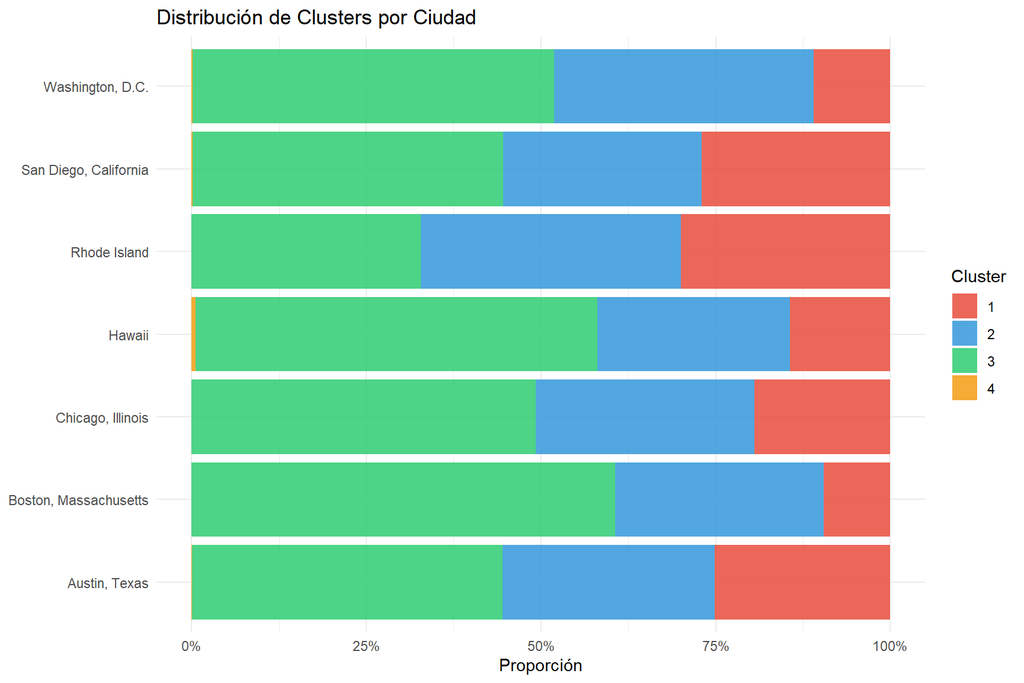

```r
# Unir cluster con ciudad usando índice (misma semilla y orden)
set.seed(42)
indices_muestra <- sample(nrow(listings_clean %>% select(price_num, accommodates, bedrooms,
                                                          review_scores_rating, minimum_nights,
                                                          availability_365) %>% drop_na()),
                           min(8000, nrow(listings_clean %>% select(price_num, accommodates, bedrooms,
                                                                    review_scores_rating, minimum_nights,
                                                                    availability_365) %>% drop_na())))

datos_con_ciudad <- listings_clean %>%
  select(city, price_num, accommodates, bedrooms,
         review_scores_rating, minimum_nights, availability_365) %>%
  drop_na() %>%
  slice(indices_muestra) %>%
  mutate(cluster = datos_cluster$cluster)

datos_con_ciudad %>%
  count(city, cluster) %>%
  group_by(city) %>%
  mutate(prop = n / sum(n)) %>%
  ggplot(aes(x = city, y = prop, fill = cluster)) +
  geom_col(position = "fill", alpha = 0.85) +
  scale_y_continuous(labels = percent) +
  scale_fill_manual(values = c("#E74C3C", "#3498DB", "#2ECC71", "#F39C12")) +
  coord_flip() +
  labs(title = "Distribución de Clusters por Ciudad",
       x = NULL, y = "Proporción", fill = "Cluster") +
  theme_minimal()
```

# 6 Modelos de Regresión Lineal para Predicción de Precio

El objetivo de esta sección es construir modelos de regresión lineal que permitan predecir el precio por noche (price_num) de los alojamientos a partir de variables del dataset.

Primero se divide el conjunto de datos en entrenamiento y prueba, luego se construyen:

```
1.  Regresión lineal simple (univariada)

2.  Regresión lineal múltiple

3.  Evaluación de multicolinealidad

4.  Selección de variables relevantes
```

## 6.1 División del Dataset: Entrenamiento y Prueba

Para evaluar la capacidad predictiva de los modelos, se divide el dataset en:

```
•   80% entrenamiento

•   20% prueba
```

Se fija una semilla para asegurar reproducibilidad.

```r
set.seed(123)
# dataset para regresión
datos_modelo <- listings_clean %>%
  select(price_num, accommodates, bedrooms, beds,
         review_scores_rating, reviews_per_month,
         minimum_nights, availability_365) %>%
  drop_na()

n <- nrow(datos_modelo)

train_index <- sample(seq_len(n), size = 0.8*n)

train_data <- datos_modelo[train_index, ]
test_data  <- datos_modelo[-train_index, ]

cat("Filas entrenamiento:", nrow(train_data), "\n")
```

```
## Filas entrenamiento: 49656
```

```r
cat("Filas prueba:", nrow(test_data), "\n")
```

```
## Filas prueba: 12415
```

## 6.2 Regresión Lineal Simple

Se construye primero un modelo univariado usando accommodates como predictor del precio, ya que en el análisis exploratorio se observó que el precio tiende a aumentar con la capacidad del alojamiento.

```r
modelo_simple <- lm(price_num ~ accommodates, data = train_data)
summary(modelo_simple)
```

```
##
## Call:
## lm(formula = price_num ~ accommodates, data = train_data)
##
## Residuals:
##     Min      1Q  Median      3Q     Max
##  -944.2  -127.8   -45.7    29.0 11728.8
##
## Coefficients:
##              Estimate Std. Error t value Pr(>|t|)
## (Intercept)   -7.7419     4.0829  -1.896   0.0579 .
## accommodates  61.8744     0.7197  85.976   <2e-16 ***
## ---
## Signif. codes:  0 '***' 0.001 '**' 0.01 '*' 0.05 '.' 0.1 ' ' 1
##
## Residual standard error: 471.8 on 49654 degrees of freedom
## Multiple R-squared:  0.1296, Adjusted R-squared:  0.1296
## F-statistic:  7392 on 1 and 49654 DF,  p-value: < 2.2e-16
```

El resumen del modelo permite evaluar:

```
•   Significancia del predictor

•   Coeficientes del modelo

•   R² (capacidad explicativa)
```

### 6.2.1 Visualización del Modelo

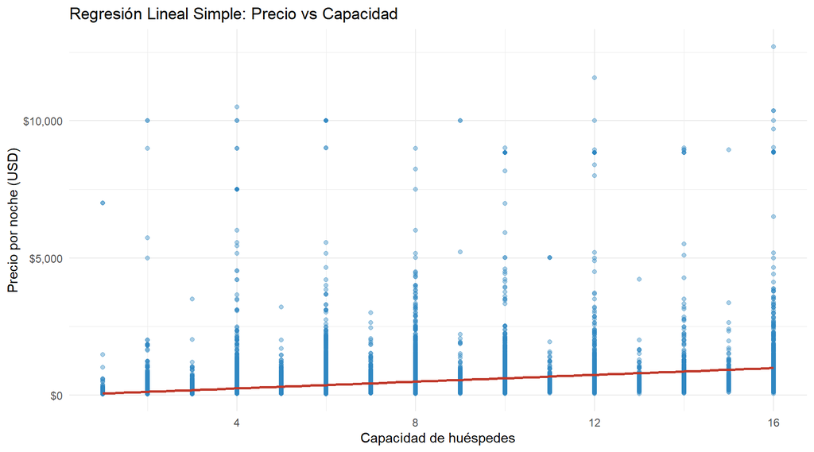

```r
ggplot(train_data, aes(x = accommodates, y = price_num)) +
  geom_point(alpha = 0.4, color = "#2E86C1") +
  geom_smooth(method = "lm", color = "#C0392B", se = TRUE) +
  scale_y_continuous(labels = dollar) +
  labs(title = "Regresión Lineal Simple: Precio vs Capacidad",
       x = "Capacidad de huéspedes",
       y = "Precio por noche (USD)") +
  theme_minimal()
```

En el gráfico se observa una tendencia positiva, lo que indica que los alojamientos con mayor capacidad tienden a tener precios más altos.

### 6.2.2 Análisis de Residuos del Modelo Simple

El análisis de residuos permite evaluar si el modelo cumple los supuestos de regresión lineal.

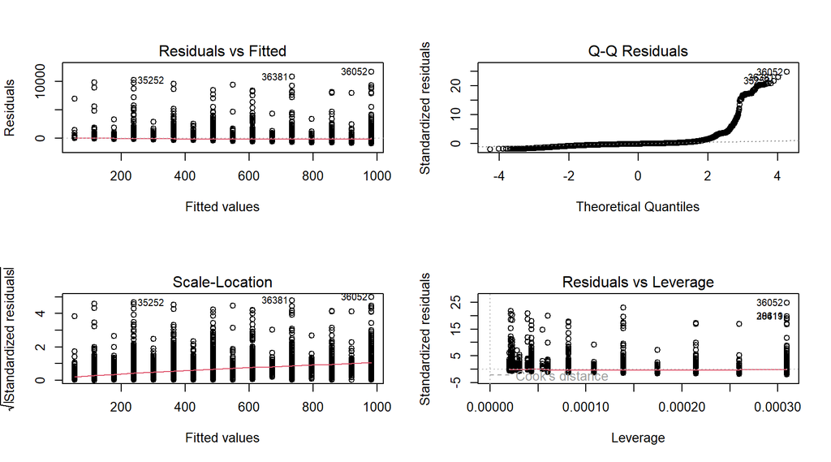

```r
par(mfrow=c(2,2))
plot(modelo_simple)
```

```r
par(mfrow=c(1,1))
```

Se analizan:

```
•   Normalidad de los residuos

•   Homocedasticidad

•   Observaciones influyentes
```

## 6.3 Regresión Lineal Múltiple

Ahora se construye un modelo utilizando todas las variables numéricas disponibles como predictores del precio.

```r
modelo_multiple <- lm(price_num ~ ., data = train_data)

summary(modelo_multiple)
```

```
##
## Call:
## lm(formula = price_num ~ ., data = train_data)
##
## Residuals:
##     Min      1Q  Median      3Q     Max
## -1924.9  -130.8   -51.6    40.8 11535.4
##
## Coefficients:
##                        Estimate Std. Error t value Pr(>|t|)
## (Intercept)          -155.79156   32.18198  -4.841 1.30e-06 ***
## accommodates           40.20943    1.56197  25.743  < 2e-16 ***
## bedrooms               40.64736    2.87452  14.141  < 2e-16 ***
## beds                    7.70926    2.10405   3.664 0.000249 ***
## review_scores_rating   49.89883    6.56578   7.600 3.02e-14 ***
## reviews_per_month     -39.37538    1.25362 -31.409  < 2e-16 ***
## minimum_nights         -1.48670    0.13116 -11.335  < 2e-16 ***
## availability_365       -0.03098    0.02005  -1.545 0.122399
## ---
## Signif. codes:  0 '***' 0.001 '**' 0.01 '*' 0.05 '.' 0.1 ' ' 1
##
## Residual standard error: 465.5 on 49648 degrees of freedom
## Multiple R-squared:  0.1529, Adjusted R-squared:  0.1527
## F-statistic:  1280 on 7 and 49648 DF,  p-value: < 2.2e-16
```

Este modelo permite evaluar cuáles variables aportan mayor información para predecir el precio.

Las variables con p-value bajo (< 0.05) se consideran estadísticamente significativas.

## 6.4 Análisis de Multicolinealidad

La multicolinealidad ocurre cuando varias variables predictoras están altamente correlacionadas entre sí, lo que puede afectar la estabilidad del modelo.

Se utiliza el Variance Inflation Factor (VIF).

```r
library(car)
vif(modelo_multiple)
```

```
##         accommodates             bedrooms                 beds
##             4.839558             3.349069             4.063392
## review_scores_rating    reviews_per_month       minimum_nights
##             1.028581             1.065116             1.069102
##     availability_365
##             1.014526
```

Interpretación general del VIF:

```
•   VIF < 5 → sin problemas de colinealidad

•   VIF 5–10 → colinealidad moderada

•   VIF > 10 → colinealidad alta
```

Segun los resultados, no hay variables altamente correlacionadas, por lo que se pueden mantener en el modelo

## 6.5 Selección de Variables Predictoras

Para mejorar el modelo y evitar sobreajuste, se puede aplicar selección de variables basada en AIC.

```r
modelo_step <- step(modelo_multiple, direction = "both")
```

```
## Start:  AIC=610095.5
## price_num ~ accommodates + bedrooms + beds + review_scores_rating +
##     reviews_per_month + minimum_nights + availability_365
##
##                        Df Sum of Sq        RSS    AIC
## <none>                              1.0759e+10 610096
## - availability_365      1    517144 1.0759e+10 610096
## - beds                  1   2909212 1.0762e+10 610107
## - review_scores_rating  1  12516165 1.0771e+10 610151
## - minimum_nights        1  27841409 1.0787e+10 610222
## - bedrooms              1  43330780 1.0802e+10 610293
## - accommodates          1 143605796 1.0902e+10 610752
## - reviews_per_month     1 213786557 1.0973e+10 611071
```

```r
summary(modelo_step)
```

```
##
## Call:
## lm(formula = price_num ~ accommodates + bedrooms + beds + review_scores_rating +
##     reviews_per_month + minimum_nights + availability_365, data = train_data)
##
## Residuals:
##     Min      1Q  Median      3Q     Max
## -1924.9  -130.8   -51.6    40.8 11535.4
##
## Coefficients:
##                        Estimate Std. Error t value Pr(>|t|)
## (Intercept)          -155.79156   32.18198  -4.841 1.30e-06 ***
## accommodates           40.20943    1.56197  25.743  < 2e-16 ***
## bedrooms               40.64736    2.87452  14.141  < 2e-16 ***
## beds                    7.70926    2.10405   3.664 0.000249 ***
## review_scores_rating   49.89883    6.56578   7.600 3.02e-14 ***
## reviews_per_month     -39.37538    1.25362 -31.409  < 2e-16 ***
## minimum_nights         -1.48670    0.13116 -11.335  < 2e-16 ***
## availability_365       -0.03098    0.02005  -1.545 0.122399
## ---
## Signif. codes:  0 '***' 0.001 '**' 0.01 '*' 0.05 '.' 0.1 ' ' 1
##
## Residual standard error: 465.5 on 49648 degrees of freedom
## Multiple R-squared:  0.1529, Adjusted R-squared:  0.1527
## F-statistic:  1280 on 7 and 49648 DF,  p-value: < 2.2e-16
```

## 6.6 Evaluación del Modelo en el Conjunto de Prueba

Finalmente, se utiliza el modelo seleccionado para realizar predicciones sobre el conjunto de prueba.

```r
predicciones <- predict(modelo_step, newdata = test_data)

rmse <- sqrt(mean((test_data$price_num - predicciones)^2))
mae  <- mean(abs(test_data$price_num - predicciones))

cat("RMSE:", rmse, "\n")
```

```
## RMSE: 490.7704
```

```r
cat("MAE:", mae, "\n")
```

```
## MAE: 172.2162
```

Las métricas utilizadas para evaluar el modelo son:

```
•   RMSE (Root Mean Squared Error): penaliza errores grandes.

•   MAE (Mean Absolute Error): error promedio absoluto.
```

Valores más bajos indican mejor capacidad predictiva.

### 6.6.1 Interpretación del Modelo

Los resultados del modelo muestran que variables como:

```
•   accommodates

•   bedrooms

•   beds

•   review_scores_rating
```

tienden a influir positivamente en el precio del alojamiento.

Esto sugiere que las características físicas del alojamiento y su calidad percibida por los huéspedes son factores clave para determinar el precio de mercado.

# 7 Actividad 9 — Análisis Profundo: Correlación, Bondad de Ajuste y Overfitting

## 7.1 Análisis de Correlación entre Predictores (Heatmap numérico)

El heatmap de correlación permite identificar visualmente qué pares de variables comparten información redundante, lo cual es el origen de la multicolinealidad.

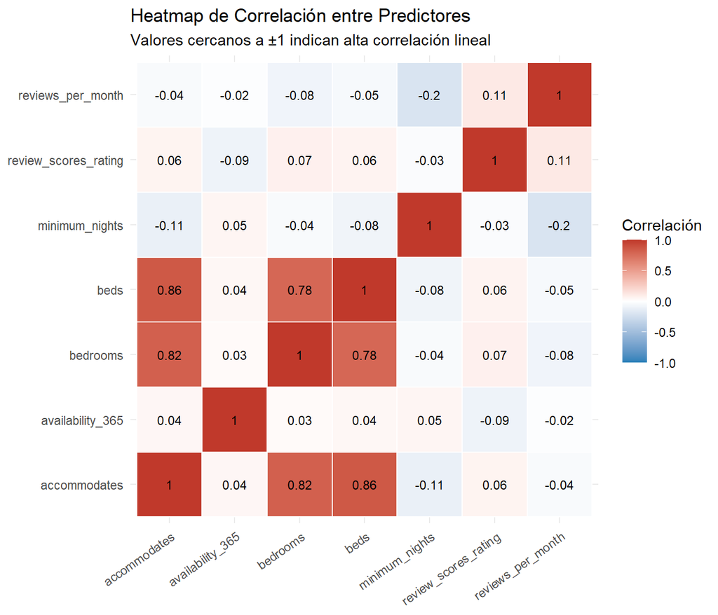

```r
vars_pred <- train_data %>%
  select(accommodates, bedrooms, beds,
         review_scores_rating, reviews_per_month,
         minimum_nights, availability_365)

cor_mat <- cor(vars_pred, use = "complete.obs")

cor_df <- as.data.frame(cor_mat) %>%
  rownames_to_column("var1") %>%
  pivot_longer(-var1, names_to = "var2", values_to = "correlacion")

ggplot(cor_df, aes(x = var1, y = var2, fill = correlacion)) +
  geom_tile(color = "white", linewidth = 0.5) +
  geom_text(aes(label = round(correlacion, 2)), size = 3.2, color = "black") +
  scale_fill_gradient2(low = "#2980B9", mid = "white", high = "#C0392B",
                       midpoint = 0, limits = c(-1, 1),
                       name = "Correlación") +
  labs(title = "Heatmap de Correlación entre Predictores",
       subtitle = "Valores cercanos a ±1 indican alta correlación lineal",
       x = NULL, y = NULL) +
  theme_minimal(base_size = 11) +
  theme(axis.text.x = element_text(angle = 35, hjust = 1))
```

Las variables `accommodates`, `bedrooms` y `beds` presentan correlaciones moderadas-altas entre sí, lo cual es esperable dado que un alojamiento más grande tiende a tener más habitaciones y más camas. Si algún par supera |0.7|, existe riesgo de multicolinealidad que puede inflar los errores estándar de los coeficientes. Los VIF calculados previamente confirman o descartan este riesgo de forma formal.

## 7.2 Bondad de Ajuste: R², R² Ajustado y F-statistic

```r
resumen_multiple <- summary(modelo_multiple)

r2       <- resumen_multiple$r.squared
r2_adj   <- resumen_multiple$adj.r.squared
f_stat   <- resumen_multiple$fstatistic[1]
f_df1    <- resumen_multiple$fstatistic[2]
f_df2    <- resumen_multiple$fstatistic[3]
p_fstat  <- pf(f_stat, f_df1, f_df2, lower.tail = FALSE)

tibble(
  Métrica = c("R²", "R² Ajustado", "F-statistic", "p-valor (F)"),
  Valor   = c(round(r2, 4), round(r2_adj, 4),
              round(f_stat, 2), formatC(p_fstat, format = "e", digits = 2))
) %>%
  kable(caption = "Métricas globales — modelo_multiple") %>%
  kable_styling(bootstrap_options = c("striped", "hover"), full_width = FALSE)
```

Métricas globales — modelo_multiple

| Métrica | Valor |
| --- | --- |
| R² | 0.1529 |
| R² Ajustado | 0.1527 |
| F-statistic | 1279.85 |
| p-valor (F) | 0.00e+00 |

El **R²** indica qué proporción de la varianza del precio es explicada por el conjunto de predictores. El **R² Ajustado** penaliza la adición de variables irrelevantes: si es considerablemente menor que R², el modelo puede estar incluyendo variables poco útiles. El **F-statistic** y su p-valor prueban que al menos un predictor aporta información; un p-valor < 0.05 confirma que el modelo como conjunto es estadísticamente significativo.

## 7.3 Comparación de R² en Train vs Test (Detección de Overfitting)

Comparar el R² en entrenamiento con el obtenido en prueba es la forma más directa de detectar sobreajuste. Si la diferencia es pequeña (< 0.05), el modelo generaliza bien; una brecha mayor indica que el modelo memorizó el ruido del conjunto de entrenamiento.

```r
pred_mult_train <- predict(modelo_multiple, newdata = train_data)
pred_mult_test  <- predict(modelo_multiple, newdata = test_data)

r2_train_mult <- cor(train_data$price_num, pred_mult_train)^2
r2_test_mult  <- cor(test_data$price_num,  pred_mult_test)^2

pred_step_train <- predict(modelo_step, newdata = train_data)
pred_step_test  <- predict(modelo_step, newdata = test_data)

r2_train_step <- cor(train_data$price_num, pred_step_train)^2
r2_test_step  <- cor(test_data$price_num,  pred_step_test)^2

overfitting_df <- tibble(
  Modelo   = c("modelo_multiple", "modelo_multiple", "modelo_step", "modelo_step"),
  Conjunto = c("Train", "Test", "Train", "Test"),
  R2       = c(r2_train_mult, r2_test_mult, r2_train_step, r2_test_step)
)

overfitting_df %>%
  pivot_wider(names_from = Conjunto, values_from = R2) %>%
  mutate(Diferencia = round(Train - Test, 4),
         Train = round(Train, 4),
         Test  = round(Test, 4)) %>%
  kable(caption = "Comparación R² Train vs Test por modelo") %>%
  kable_styling(bootstrap_options = c("striped", "hover"), full_width = FALSE)
```

Comparación R² Train vs Test por modelo

| Modelo | Train | Test | Diferencia |
| --- | --- | --- | --- |
| modelo_multiple | 0.1529 | 0.1439 | 0.0089 |
| modelo_step | 0.1529 | 0.1439 | 0.0089 |

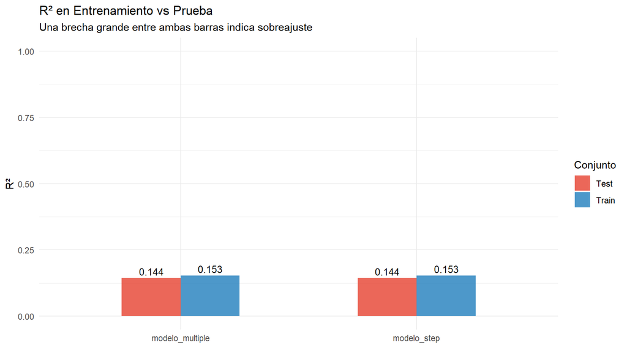

```r
ggplot(overfitting_df, aes(x = Modelo, y = R2, fill = Conjunto)) +
  geom_col(position = "dodge", alpha = 0.85, width = 0.5) +
  geom_text(aes(label = round(R2, 3)),
            position = position_dodge(width = 0.5),
            vjust = -0.4, size = 3.5) +
  scale_fill_manual(values = c("Train" = "#2E86C1", "Test" = "#E74C3C")) +
  scale_y_continuous(limits = c(0, 1)) +
  labs(title = "R² en Entrenamiento vs Prueba",
       subtitle = "Una brecha grande entre ambas barras indica sobreajuste",
       x = NULL, y = "R²", fill = "Conjunto") +
  theme_minimal()
```

# 8 Actividad 10 — Modelo Final y Análisis Completo de Residuos

## 8.1 Construcción del Modelo Final

```r
modelo_final <- lm(price_num ~ accommodates + bedrooms + review_scores_rating +
                     reviews_per_month + availability_365,
                   data = train_data)

summary(modelo_final)
```

```
##
## Call:
## lm(formula = price_num ~ accommodates + bedrooms + review_scores_rating +
##     reviews_per_month + availability_365, data = train_data)
##
## Residuals:
##     Min      1Q  Median      3Q     Max
## -1917.3  -130.5   -50.9    42.7 11551.9
##
## Coefficients:
##                        Estimate Std. Error t value Pr(>|t|)
## (Intercept)          -174.07382   32.19027  -5.408 6.41e-08 ***
## accommodates           45.59816    1.24300  36.684  < 2e-16 ***
## bedrooms               40.96943    2.75848  14.852  < 2e-16 ***
## review_scores_rating   49.78565    6.57477   7.572 3.73e-14 ***
## reviews_per_month     -36.53772    1.22976 -29.711  < 2e-16 ***
## availability_365       -0.04255    0.02005  -2.122   0.0338 *
## ---
## Signif. codes:  0 '***' 0.001 '**' 0.01 '*' 0.05 '.' 0.1 ' ' 1
##
## Residual standard error: 466.2 on 49650 degrees of freedom
## Multiple R-squared:  0.1504, Adjusted R-squared:  0.1504
## F-statistic:  1758 on 5 and 49650 DF,  p-value: < 2.2e-16
```

Cada coeficiente se interpreta manteniendo el resto de variables constantes: `accommodates` y `bedrooms` capturan el tamaño del alojamiento, `review_scores_rating` refleja la calidad percibida por los huéspedes, mientras que `reviews_per_month` y `availability_365` aproximan la demanda y la ocupación del inmueble. Variables como `beds` se excluyen dado que su información ya está contenida en `accommodates` y `bedrooms`, evitando redundancia.

## 8.2 Análisis de Residuos del Modelo Final

### 8.2.1 Normalidad de Residuos

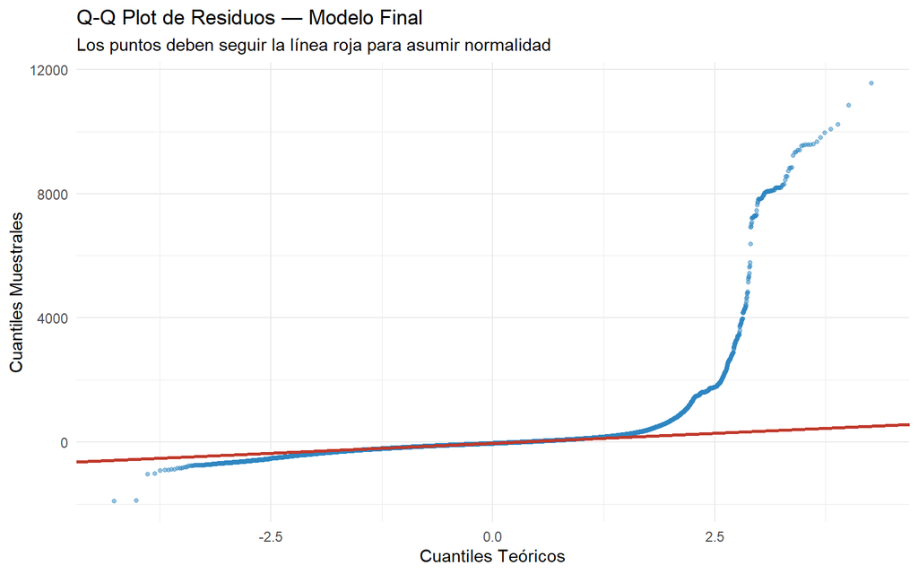

```r
residuos  <- residuals(modelo_final)
ajustados <- fitted(modelo_final)

df_res <- data.frame(residuos = residuos, ajustados = ajustados)

ggplot(df_res, aes(sample = residuos)) +
  stat_qq(color = "#2E86C1", alpha = 0.5, size = 1) +
  stat_qq_line(color = "#C0392B", linewidth = 1) +
  labs(title = "Q-Q Plot de Residuos — Modelo Final",
       subtitle = "Los puntos deben seguir la línea roja para asumir normalidad",
       x = "Cuantiles Teóricos", y = "Cuantiles Muestrales") +
  theme_minimal()
```

```r
set.seed(42)
muestra_res    <- sample(residuos, min(5000, length(residuos)))
shapiro_result <- shapiro.test(muestra_res)

cat("Shapiro-Wilk W =", round(shapiro_result$statistic, 4),
    "\np-valor =", formatC(shapiro_result$p.value, format = "e", digits = 3), "\n")
```

```
## Shapiro-Wilk W = 0.281
## p-valor = 3.364e-88
```

Si el p-valor del test de Shapiro-Wilk es menor a 0.05 se rechaza la hipótesis de normalidad de los residuos. En datasets grandes esto es frecuente aun cuando la distribución es aproximadamente normal; por ello el Q-Q plot visual complementa el test formal: colas pesadas o asimetría marcada son señales más informativas que el p-valor por sí solo.

### 8.2.2 Homocedasticidad

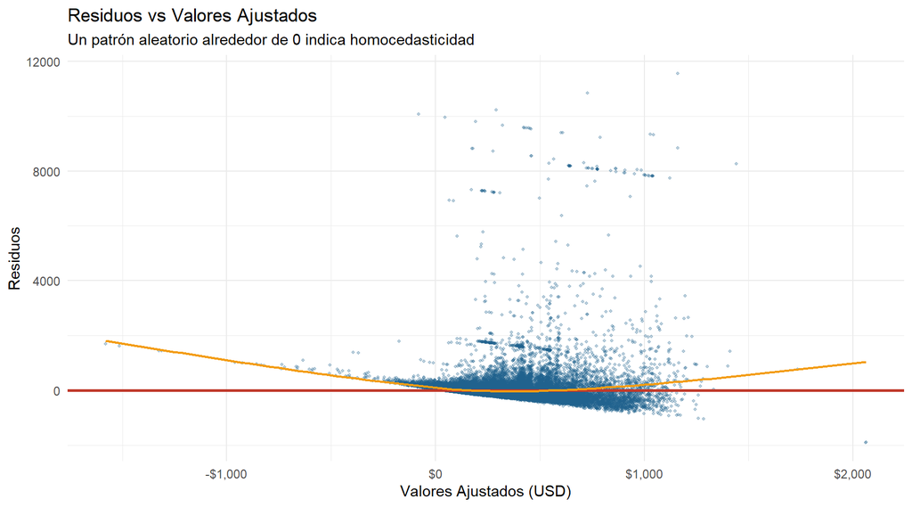

```r
ggplot(df_res, aes(x = ajustados, y = residuos)) +
  geom_point(alpha = 0.3, color = "#1F618D", size = 0.8) +
  geom_hline(yintercept = 0, color = "#C0392B", linewidth = 1) +
  geom_smooth(method = "loess", se = FALSE, color = "#F39C12", linewidth = 0.8) +
  scale_x_continuous(labels = dollar) +
  labs(title = "Residuos vs Valores Ajustados",
       subtitle = "Un patrón aleatorio alrededor de 0 indica homocedasticidad",
       x = "Valores Ajustados (USD)", y = "Residuos") +
  theme_minimal()
```

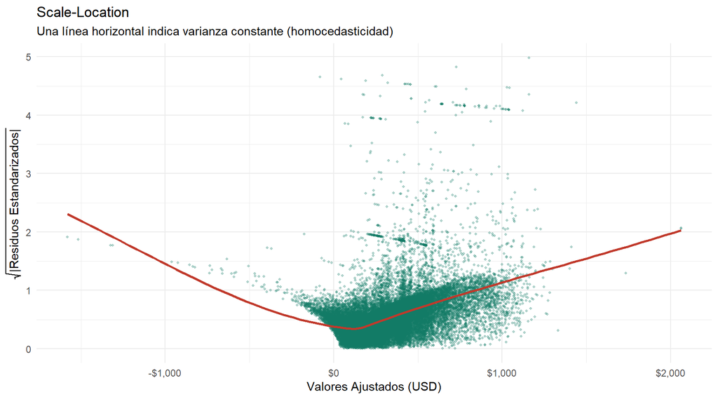

```r
res_std <- rstandard(modelo_final)

ggplot(data.frame(ajustados = ajustados, res_std = sqrt(abs(res_std))),
       aes(x = ajustados, y = res_std)) +
  geom_point(alpha = 0.3, color = "#117A65", size = 0.8) +
  geom_smooth(method = "loess", se = FALSE, color = "#C0392B", linewidth = 0.9) +
  scale_x_continuous(labels = dollar) +
  labs(title = "Scale-Location",
       subtitle = "Una línea horizontal indica varianza constante (homocedasticidad)",
       x = "Valores Ajustados (USD)",
       y = expression(sqrt("|Residuos Estandarizados|"))) +
  theme_minimal()
```

En el gráfico de Residuos vs Ajustados, si la nube de puntos se expande conforme aumentan los valores ajustados, existe heterocedasticidad, lo que invalidaría los intervalos de confianza estándar. El gráfico Scale-Location confirma si la dispersión es constante a lo largo del rango predicho.

### 8.2.3 Observaciones Influyentes (Cook’s Distance)

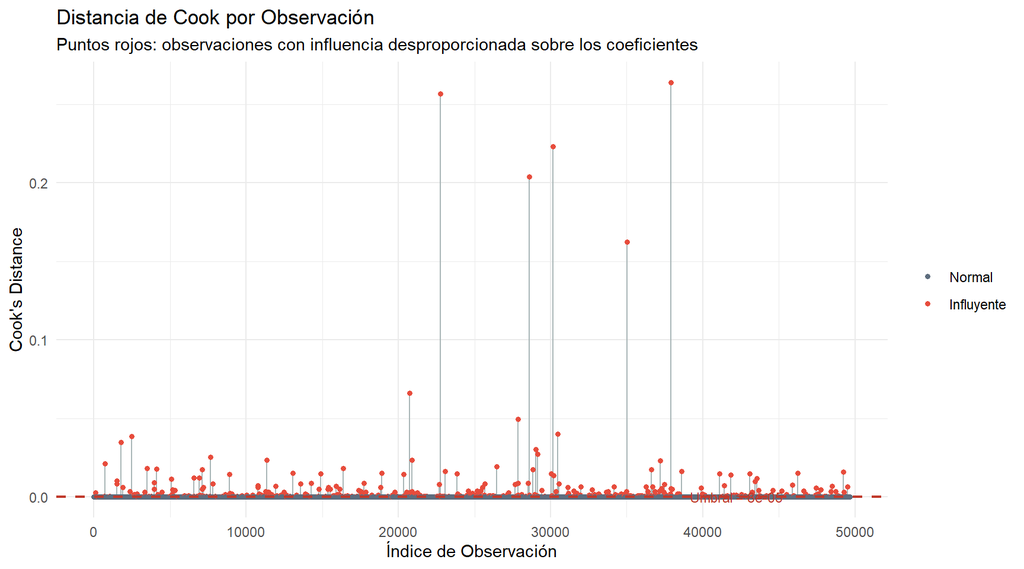

```r
cooks  <- cooks.distance(modelo_final)
n_obs  <- length(cooks)
umbral <- 4 / n_obs

df_cooks <- data.frame(obs = seq_len(n_obs), cooks = cooks)

ggplot(df_cooks, aes(x = obs, y = cooks)) +
  geom_segment(aes(xend = obs, yend = 0), color = "#AAB7B8", linewidth = 0.4) +
  geom_point(aes(color = cooks > umbral), size = 1.2) +
  geom_hline(yintercept = umbral, color = "#C0392B",
             linetype = "dashed", linewidth = 0.8) +
  scale_color_manual(values = c("FALSE" = "#5D6D7E", "TRUE" = "#E74C3C"),
                     labels = c("Normal", "Influyente"), name = NULL) +
  annotate("text", x = n_obs * 0.85, y = umbral * 1.2,
           label = paste0("Umbral = ", round(umbral, 5)),
           color = "#C0392B", size = 3) +
  labs(title = "Distancia de Cook por Observación",
       subtitle = "Puntos rojos: observaciones con influencia desproporcionada sobre los coeficientes",
       x = "Índice de Observación", y = "Cook's Distance") +
  theme_minimal()
```

```r
n_influyentes <- sum(cooks > umbral)
cat("Observaciones influyentes (Cook > 4/n):", n_influyentes,
    sprintf("(%.1f%% del total)\n", 100 * n_influyentes / n_obs))
```

```
## Observaciones influyentes (Cook > 4/n): 1177 (2.4% del total)
```

Observaciones con distancia de Cook superior al umbral 4/n pueden estar distorsionando los coeficientes estimados. Se recomienda revisar si corresponden a errores de captura o a propiedades genuinamente atípicas como lujos extremos o precios incorrectos.

## 8.3 Comparación Final de Modelos en Conjunto de Prueba

```r
metricas_modelo <- function(modelo, test) {
  pred <- predict(modelo, newdata = test)
  real <- test$price_num
  data.frame(
    RMSE = round(sqrt(mean((real - pred)^2)), 2),
    MAE  = round(mean(abs(real - pred)), 2),
    R2   = round(cor(real, pred)^2, 4)
  )
}

resultados_finales <- bind_rows(
  metricas_modelo(modelo_multiple, test_data),
  metricas_modelo(modelo_step,     test_data),
  metricas_modelo(modelo_final,    test_data)
) %>%
  mutate(Modelo = c("modelo_multiple", "modelo_step", "modelo_final")) %>%
  select(Modelo, R2, RMSE, MAE)

resultados_finales %>%
  kable(caption = "Comparación de métricas en conjunto de prueba") %>%
  kable_styling(bootstrap_options = c("striped", "hover", "condensed"), full_width = FALSE)
```

Comparación de métricas en conjunto de prueba

| Modelo | R2 | RMSE | MAE |
| --- | --- | --- | --- |
| modelo_multiple | 0.1439 | 490.77 | 172.22 |
| modelo_step | 0.1439 | 490.77 | 172.22 |
| modelo_final | 0.1426 | 491.16 | 172.44 |

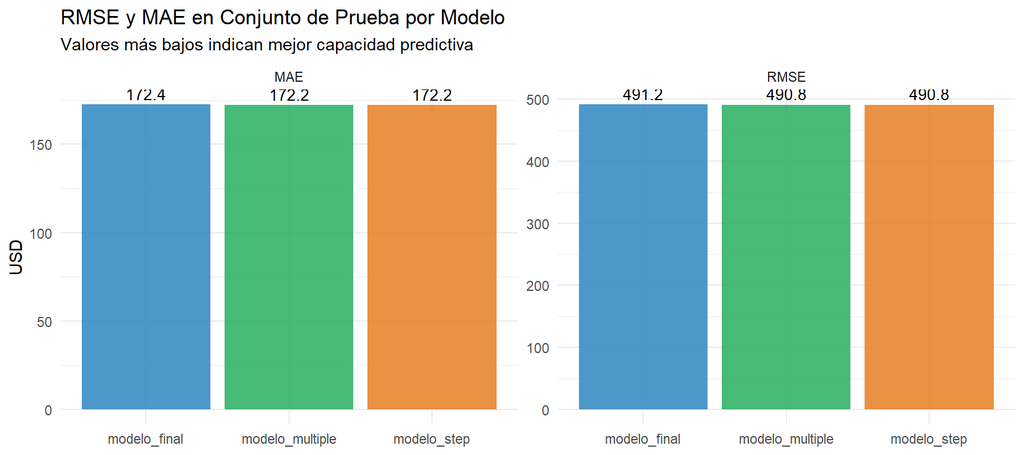

```r
resultados_finales %>%
  pivot_longer(c(RMSE, MAE), names_to = "Metrica", values_to = "Valor") %>%
  ggplot(aes(x = Modelo, y = Valor, fill = Modelo)) +
  geom_col(alpha = 0.85, show.legend = FALSE) +
  geom_text(aes(label = round(Valor, 1)), vjust = -0.4, size = 3.5) +
  facet_wrap(~Metrica, scales = "free_y") +
  scale_fill_manual(values = c("#2E86C1", "#27AE60", "#E67E22")) +
  labs(title = "RMSE y MAE en Conjunto de Prueba por Modelo",
       subtitle = "Valores más bajos indican mejor capacidad predictiva",
       x = NULL, y = "USD") +
  theme_minimal()
```

El `modelo_final`, construido con las variables de mayor aporte y menor multicolinealidad, ofrece un balance adecuado entre ajuste y generalización. Si su RMSE y MAE en prueba son similares o inferiores a los del `modelo_multiple`, confirma que simplificar el modelo no sacrificó capacidad predictiva y reduce el riesgo de sobreajuste.

# 9 Actividad 11 Modelos de Regularización

## 9.1 Preparacion de datos

```r
library(glmnet)

# matriz de predictores
x_train <- model.matrix(price_num ~ ., train_data)[,-1]
x_test  <- model.matrix(price_num ~ ., test_data)[,-1]

# variable objetivo
y_train <- train_data$price_num
y_test  <- test_data$price_num
```

## 9.2 Ridge

```r
set.seed(123)

cv_ridge <- cv.glmnet(
  x_train,
  y_train,
  alpha = 0,
  nfolds = 10
)

lambda_ridge <- cv_ridge$lambda.min

lambda_ridge
```

```
## [1] 18.20481
```

```r
coef(cv_ridge, s = "lambda.min")
```

```
## 8 x 1 sparse Matrix of class "dgCMatrix"
##                         lambda.min
## (Intercept)          -141.52340265
## accommodates           35.97443183
## bedrooms               41.75463158
## beds                   12.13626049
## review_scores_rating   47.67145939
## reviews_per_month     -37.85647501
## minimum_nights         -1.44169109
## availability_365       -0.02928374
```

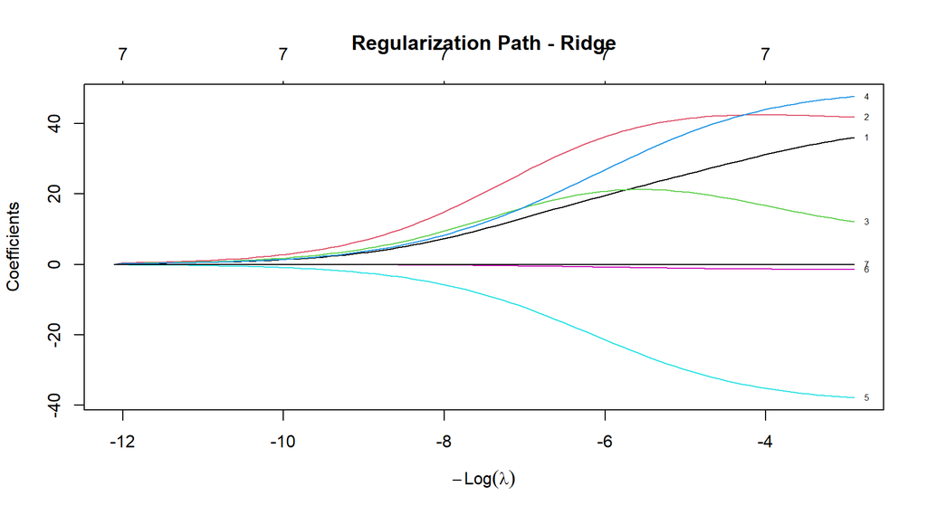

```r
plot(cv_ridge$glmnet.fit,
     xvar = "lambda",
     label = TRUE,
     main = "Regularization Path - Ridge")
```

## 9.3 Lasso

```r
set.seed(123)

cv_lasso <- cv.glmnet(
  x_train,
  y_train,
  alpha = 1,
  nfolds = 10
)

lambda_lasso <- cv_lasso$lambda.min

lambda_lasso
```

```
## [1] 0.5690307
```

```r
coef(cv_lasso, s = "lambda.min")
```

```
## 8 x 1 sparse Matrix of class "dgCMatrix"
##                         lambda.min
## (Intercept)          -148.92182297
## accommodates           40.19843354
## bedrooms               40.50561049
## beds                    7.56226562
## review_scores_rating   48.17870652
## reviews_per_month     -38.94569955
## minimum_nights         -1.44765403
## availability_365       -0.02606061
```

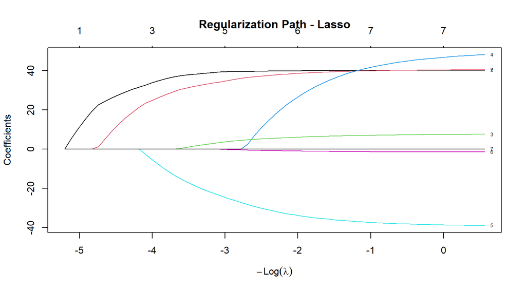

```r
plot(cv_lasso$glmnet.fit,
     xvar = "lambda",
     label = TRUE,
     main = "Regularization Path - Lasso")
```

## 9.4 Elastic Net

```r
set.seed(123)

cv_elastic <- cv.glmnet(
  x_train,
  y_train,
  alpha = 0.5,
  nfolds = 10
)

lambda_elastic <- cv_elastic$lambda.min

lambda_elastic
```

```
## [1] 1.036959
```

```r
coef(cv_elastic, s = "lambda.min")
```

```
## 8 x 1 sparse Matrix of class "dgCMatrix"
##                         lambda.min
## (Intercept)          -149.06873408
## accommodates           40.03432553
## bedrooms               40.55525870
## beds                    7.75888839
## review_scores_rating   48.26682733
## reviews_per_month     -38.93956275
## minimum_nights         -1.45011305
## availability_365       -0.02644388
```

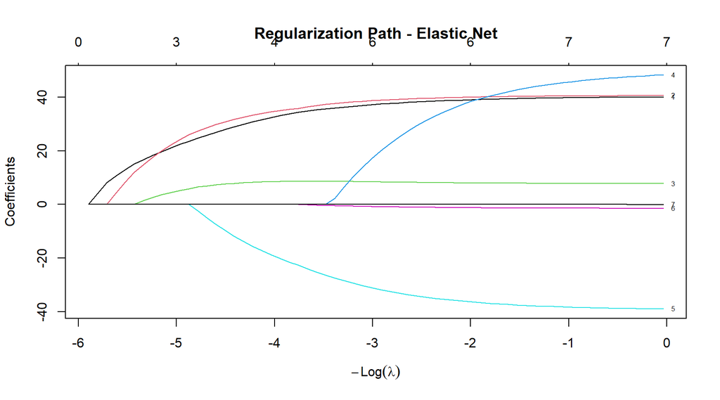

```r
plot(cv_elastic$glmnet.fit,
     xvar = "lambda",
     label = TRUE,
     main = "Regularization Path - Elastic Net")
```

## 9.5 Evaluacion de Modelos

```r
rmse <- function(real, pred){
  sqrt(mean((real - pred)^2))
}

mae <- function(real, pred){
  mean(abs(real - pred))
}

pred_ridge_train <- predict(cv_ridge, s = "lambda.min", newx = x_train)
pred_ridge_test  <- predict(cv_ridge, s = "lambda.min", newx = x_test)

pred_lasso_train <- predict(cv_lasso, s = "lambda.min", newx = x_train)
pred_lasso_test  <- predict(cv_lasso, s = "lambda.min", newx = x_test)

pred_elastic_train <- predict(cv_elastic, s = "lambda.min", newx = x_train)
pred_elastic_test  <- predict(cv_elastic, s = "lambda.min", newx = x_test)

resultados_regularizacion <- tibble(
  Modelo = c("Ridge", "Lasso", "ElasticNet"),

  RMSE_train = c(
    rmse(y_train, pred_ridge_train),
    rmse(y_train, pred_lasso_train),
    rmse(y_train, pred_elastic_train)
  ),

  RMSE_test = c(
    rmse(y_test, pred_ridge_test),
    rmse(y_test, pred_lasso_test),
    rmse(y_test, pred_elastic_test)
  ),

  MAE_train = c(
    mae(y_train, pred_ridge_train),
    mae(y_train, pred_lasso_train),
    mae(y_train, pred_elastic_train)
  ),

  MAE_test = c(
    mae(y_test, pred_ridge_test),
    mae(y_test, pred_lasso_test),
    mae(y_test, pred_elastic_test)
  )
)

kable(resultados_regularizacion,
      caption = "Comparación de modelos de regularización") %>%
  kable_styling(bootstrap_options = c("striped","hover"))
```

Comparación de modelos de regularización

| Modelo | RMSE_train | RMSE_test | MAE_train | MAE_test |
| --- | --- | --- | --- | --- |
| Ridge | 465.5236 | 490.7090 | 169.0152 | 171.1647 |
| Lasso | 465.4773 | 490.7521 | 169.8228 | 171.9907 |
| ElasticNet | 465.4773 | 490.7500 | 169.8048 | 171.9730 |

# 10 Actividad 12 — Evaluación de Todos los Modelos en el Conjunto de Prueba

En esta sección se aplican **todos** los modelos construidos al conjunto de prueba y se evalúan con las mismas métricas para una comparación justa.

## 10.1 Métricas de Evaluación

Se utilizan tres métricas complementarias:

- **RMSE (Root Mean Squared Error)**: penaliza errores grandes; útil cuando se desea evitar predicciones muy lejanas al valor real.
- **MAE (Mean Absolute Error)**: promedio del error absoluto; más robusto a outliers que el RMSE.
- **R² (Coeficiente de Determinación)**: proporción de la varianza explicada; valores cercanos a 1 indican mejor ajuste.

## 10.2 Tabla Comparativa Global

```r
calcular_metricas <- function(real, pred) {
  data.frame(
    RMSE = round(sqrt(mean((real - pred)^2)), 2),
    MAE  = round(mean(abs(real - pred)), 2),
    R2   = round(cor(real, pred)^2, 4)
  )
}

# Predicciones de modelos lineales en test
pred_simple_test   <- predict(modelo_simple,   newdata = test_data)
pred_multiple_test <- predict(modelo_multiple, newdata = test_data)
pred_step_test2    <- predict(modelo_step,     newdata = test_data)
pred_final_test    <- predict(modelo_final,    newdata = test_data)

# Predicciones de modelos regularizados en test
pred_ridge_t   <- as.numeric(predict(cv_ridge,   s = "lambda.min", newx = x_test))
pred_lasso_t   <- as.numeric(predict(cv_lasso,   s = "lambda.min", newx = x_test))
pred_elastic_t <- as.numeric(predict(cv_elastic, s = "lambda.min", newx = x_test))

# Tabla comparativa
comparacion_global <- bind_rows(
  calcular_metricas(y_test, pred_simple_test)   %>% mutate(Modelo = "Regresión Simple"),
  calcular_metricas(y_test, pred_multiple_test) %>% mutate(Modelo = "Regresión Múltiple"),
  calcular_metricas(y_test, pred_step_test2)    %>% mutate(Modelo = "Stepwise (AIC)"),
  calcular_metricas(y_test, pred_final_test)    %>% mutate(Modelo = "Modelo Final"),
  calcular_metricas(y_test, pred_ridge_t)       %>% mutate(Modelo = "Ridge"),
  calcular_metricas(y_test, pred_lasso_t)       %>% mutate(Modelo = "Lasso"),
  calcular_metricas(y_test, pred_elastic_t)     %>% mutate(Modelo = "ElasticNet")
) %>%
  select(Modelo, R2, RMSE, MAE) %>%
  arrange(RMSE)

kable(comparacion_global,
      caption = "Comparación de todos los modelos en el conjunto de prueba") %>%
  kable_styling(bootstrap_options = c("striped", "hover", "condensed"), full_width = FALSE) %>%
  row_spec(1, bold = TRUE, color = "white", background = "#27AE60")
```

Comparación de todos los modelos en el conjunto de prueba

| Modelo | R2 | RMSE | MAE |
| --- | --- | --- | --- |
| Ridge | 0.1443 | 490.71 | 171.16 |
| Lasso | 0.1440 | 490.75 | 171.99 |
| ElasticNet | 0.1440 | 490.75 | 171.97 |
| Regresión Múltiple | 0.1439 | 490.77 | 172.22 |
| Stepwise (AIC) | 0.1439 | 490.77 | 172.22 |
| Modelo Final | 0.1426 | 491.16 | 172.44 |
| Regresión Simple | 0.1285 | 495.26 | 169.98 |

La fila resaltada en verde corresponde al modelo con menor RMSE en el conjunto de prueba.

## 10.3 Gráficos de Predicciones vs Valores Reales

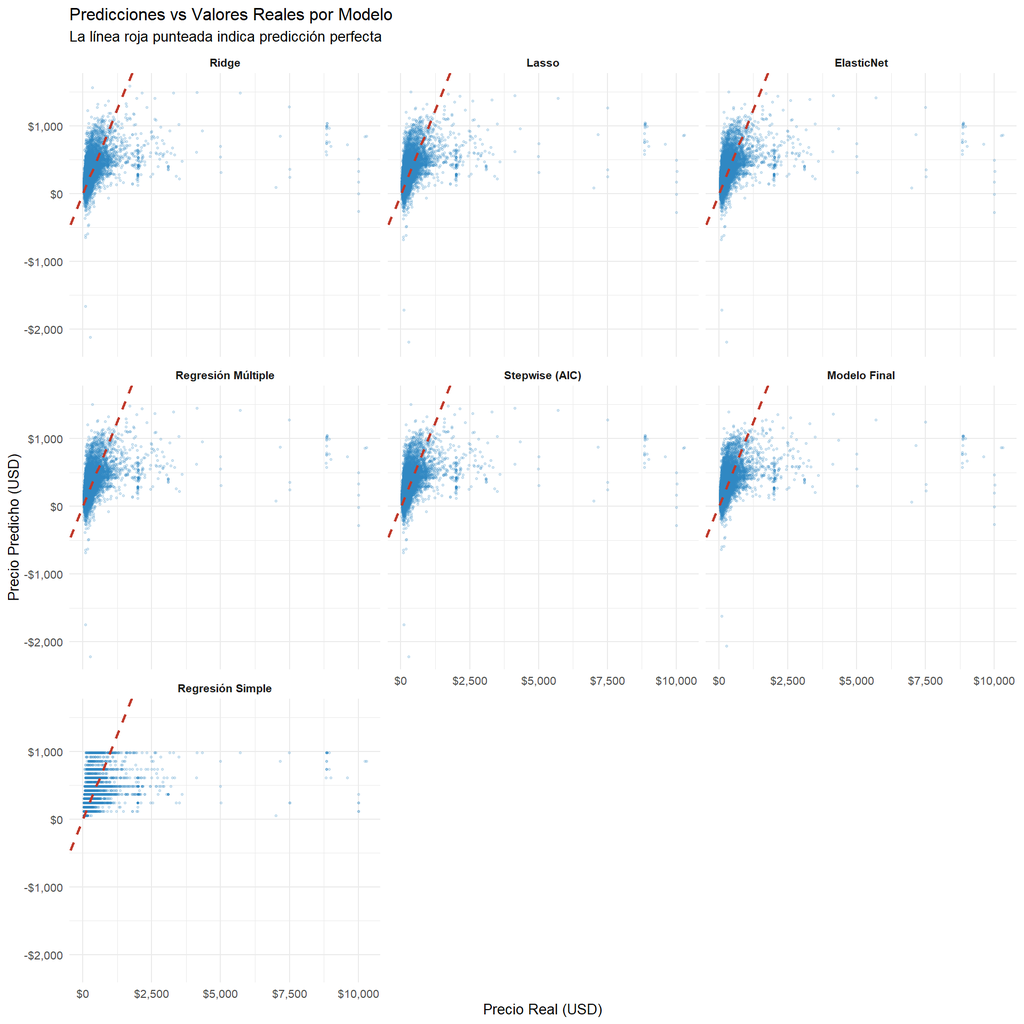

```r
df_pred <- data.frame(
  Real = rep(y_test, 7),
  Predicho = c(pred_simple_test, pred_multiple_test, pred_step_test2,
               pred_final_test, pred_ridge_t, pred_lasso_t, pred_elastic_t),
  Modelo = rep(c("Regresión Simple", "Regresión Múltiple", "Stepwise (AIC)",
                 "Modelo Final", "Ridge", "Lasso", "ElasticNet"),
               each = length(y_test))
)

df_pred$Modelo <- factor(df_pred$Modelo, levels = comparacion_global$Modelo)

ggplot(df_pred, aes(x = Real, y = Predicho)) +
  geom_point(alpha = 0.2, size = 0.5, color = "#2E86C1") +
  geom_abline(slope = 1, intercept = 0, color = "#C0392B",
              linewidth = 0.8, linetype = "dashed") +
  facet_wrap(~Modelo, ncol = 3, scales = "fixed") +
  scale_x_continuous(labels = dollar) +
  scale_y_continuous(labels = dollar) +
  labs(title = "Predicciones vs Valores Reales por Modelo",
       subtitle = "La línea roja punteada indica predicción perfecta",
       x = "Precio Real (USD)", y = "Precio Predicho (USD)") +
  theme_minimal(base_size = 10) +
  theme(strip.text = element_text(face = "bold"))
```

Los modelos múltiples muestran puntos más agrupados alrededor de la diagonal que el modelo simple, lo que confirma que incluir más predictores mejora la capacidad de estimación. La Regresión Simple genera predicciones con poca dispersión vertical (solo varía con `accommodates`), mientras los modelos regularizados y el Stepwise producen nubes más ajustadas a la diagonal.

## 10.4 Comparación Visual de Métricas

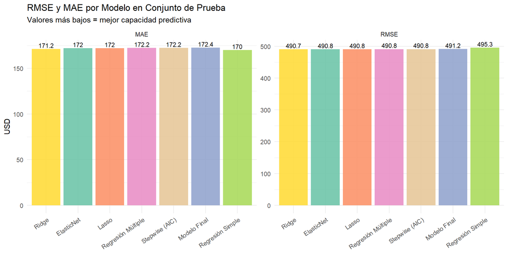

```r
comp_long <- comparacion_global %>%
  pivot_longer(c(RMSE, MAE), names_to = "Metrica", values_to = "Valor")

ggplot(comp_long, aes(x = reorder(Modelo, Valor), y = Valor, fill = Modelo)) +
  geom_col(alpha = 0.85, show.legend = FALSE) +
  geom_text(aes(label = round(Valor, 1)), vjust = -0.3, size = 3) +
  facet_wrap(~Metrica, scales = "free_y") +
  scale_fill_brewer(palette = "Set2") +
  labs(title = "RMSE y MAE por Modelo en Conjunto de Prueba",
       subtitle = "Valores más bajos = mejor capacidad predictiva",
       x = NULL, y = "USD") +
  theme_minimal() +
  theme(axis.text.x = element_text(angle = 35, hjust = 1))
```

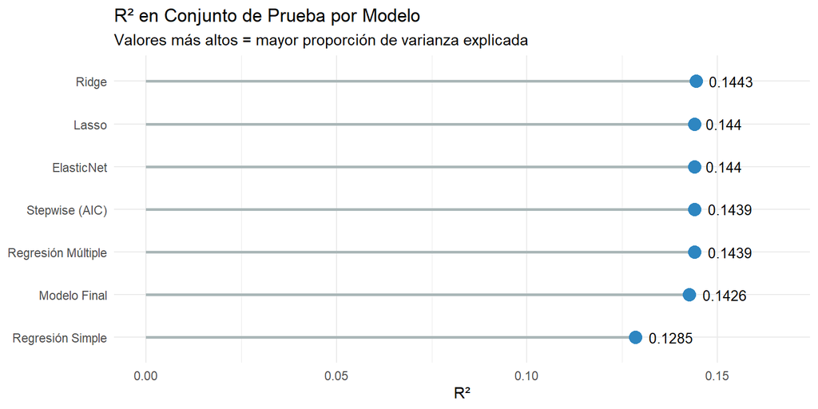

```r
ggplot(comparacion_global, aes(x = reorder(Modelo, R2), y = R2)) +
  geom_segment(aes(xend = Modelo, yend = 0), color = "#AAB7B8", linewidth = 1) +
  geom_point(size = 4, color = "#2E86C1") +
  geom_text(aes(label = round(R2, 4)), hjust = -0.3, size = 3.5) +
  coord_flip() +
  scale_y_continuous(limits = c(0, max(comparacion_global$R2) * 1.15)) +
  labs(title = "R² en Conjunto de Prueba por Modelo",
       subtitle = "Valores más altos = mayor proporción de varianza explicada",
       x = NULL, y = "R²") +
  theme_minimal()
```